# Text Mining Pipeline - N-gram

*A simple R project adapted for self-study purpose.*

In this project, we perform analysis on a customer complaint dataset with N-gram language model using R.

# Outline

- Section 1: Load Packages
- Section 2: Load Data
- Section 3: Text Cleaning
- Section 4: N-Gram Tokenization
- Section 5: Graph Plotting for N-Gram

# Section 1: Load Packages

The R packages used in this project are listed below:

- [`tm`](https://cran.r-project.org/web/packages/tm/index.html): a **text mining** package which provides many functions for text mining applications in R.
- [`RWeka`](https://cran.r-project.org/web/packages/RWeka/index.html): provides machine learning algorithms for R applications.

```r
library(tm)
library(RWeka)
```

# Section 2: Load Data

The dataset we use in this project is the [consumer complaint dataset](https://catalog.data.gov/dataset/consumer-complaint-database), which consists of 18 features (columns). For our purpose, we will only use a very small subset of the original dataset (199 records out of **3 million records from the original dataset!**)

First, read the dataset from a CSV file into a data frame.

```r
#read data from csv into dataframe
# complaintData <- read.csv("C:/r/simpleTextMining/data/complaintFinance/consumer_complaint_200.csv")
complaintData <- read.csv("../data/complaintFinance/consumer_complaint_200.csv")

#use head function to inspect first 6 rows of data
head(complaintData)
```

|  | Date.received | Product | Sub.product | Issue | Sub.issue | Consumer.complaint.narrative | Company.public.response | Company | State | ZIP.code | Tags | Consumer.consent.provided. | Submitted.via | Date.sent.to.company | Company.response.to.consumer | Timely.response. | Consumer.disputed. | Complaint.ID |
| --- | --- | --- | --- | --- | --- | --- | --- | --- | --- | --- | --- | --- | --- | --- | --- | --- | --- | --- |
| 1 | 5/10/2019 | Checking or savings account | Checking account | Managing an account | Problem using a debit or ATM card | NA |  | NAVY FEDERAL CREDIT UNION | FL | 328XX | Older American |  | Web | 5/10/2019 | In progress | Yes | N/A | 3238275 |
| 2 | 5/10/2019 | Checking or savings account | Other banking product or service | Managing an account | Deposits and withdrawals | NA |  | BOEING EMPLOYEES CREDIT UNION | WA | 98204 |  | N/A | Referral | 5/10/2019 | Closed with explanation | Yes | N/A | 3238228 |
| 3 | 5/10/2019 | Debt collection | Payday loan debt | Communication tactics | Frequent or repeated calls | NA |  | CURO Intermediate Holdings | TX | 751XX |  |  | Web | 5/10/2019 | Closed with explanation | Yes | N/A | 3237964 |
| 4 | 5/10/2019 | Credit reporting, credit repair services, or other personal consumer reports | Credit reporting | Incorrect information on your report | Old information reappears or never goes away | NA |  | Ad Astra Recovery Services Inc | LA | 708XX |  |  | Web | 5/10/2019 | Closed with explanation | Yes | N/A | 3238479 |
| 5 | 5/10/2019 | Checking or savings account | Checking account | Managing an account | Banking errors | NA |  | ALLY FINANCIAL INC. | AZ | 85205 |  | N/A | Postal mail | 5/10/2019 | In progress | Yes | N/A | 3238460 |
| 6 | 5/10/2019 | Mortgage | Other type of mortgage | Closing on a mortgage |  | NA |  | Statebridge Company | NJ | 8302 |  |  | Web | 5/10/2019 | Closed with explanation | Yes | N/A | 3237885 |

Next, read the data from data frame into `VCorpus`. Here, we use only the column: **Issue** from the data frame. Feel free to play around with other columns on you own.

Then, inspect the internal structure of the `VCorpus` by calling `str()`. Note that this function will print the internal structure for all 199 records by default. Therefore, we define `indices` which limits the function to print only the internal structure of first 3 records from `Vcorpus`.

```r
#read data from dataframe into VCorpus
#Use xxx$Issue to read data from Issue column
issueData <- VCorpus(VectorSource(complaintData$Issue))

indices <- seq(1,3)
str(issueData[indices])
```

```
List of 3
 $ 1:List of 2
  ..$ content: chr "Managing an account"
  ..$ meta   :List of 7
  .. ..$ author       : chr(0)
  .. ..$ datetimestamp: POSIXlt[1:1], format: "2020-10-29 13:07:47"
  .. ..$ description  : chr(0)
  .. ..$ heading      : chr(0)
  .. ..$ id           : chr "1"
  .. ..$ language     : chr "en"
  .. ..$ origin       : chr(0)
  .. ..- attr(*, "class")= chr "TextDocumentMeta"
  ..- attr(*, "class")= chr [1:2] "PlainTextDocument" "TextDocument"
 $ 2:List of 2
  ..$ content: chr "Managing an account"
  ..$ meta   :List of 7
  .. ..$ author       : chr(0)
  .. ..$ datetimestamp: POSIXlt[1:1], format: "2020-10-29 13:07:47"
  .. ..$ description  : chr(0)
  .. ..$ heading      : chr(0)
  .. ..$ id           : chr "2"
  .. ..$ language     : chr "en"
  .. ..$ origin       : chr(0)
  .. ..- attr(*, "class")= chr "TextDocumentMeta"
  ..- attr(*, "class")= chr [1:2] "PlainTextDocument" "TextDocument"
 $ 3:List of 2
  ..$ content: chr "Communication tactics"
  ..$ meta   :List of 7
  .. ..$ author       : chr(0)
  .. ..$ datetimestamp: POSIXlt[1:1], format: "2020-10-29 13:07:47"
  .. ..$ description  : chr(0)
  .. ..$ heading      : chr(0)
  .. ..$ id           : chr "3"
  .. ..$ language     : chr "en"
  .. ..$ origin       : chr(0)
  .. ..- attr(*, "class")= chr "TextDocumentMeta"
  ..- attr(*, "class")= chr [1:2] "PlainTextDocument" "TextDocument"
 - attr(*, "class")= chr [1:2] "VCorpus" "Corpus"
```

There are more ways to inspect the data, as demonstrated below:

```r
#view summary of corpus information
summary(issueData[indices])
```

```
  Length Class             Mode
1 2      PlainTextDocument list
2 2      PlainTextDocument list
3 2      PlainTextDocument list
```

```r
#inspect data for all records
inspect(issueData[indices])
```

```
<<VCorpus>>
Metadata:  corpus specific: 0, document level (indexed): 0
Content:  documents: 3

[[1]]
<<PlainTextDocument>>
Metadata:  7
Content:  chars: 19

[[2]]
<<PlainTextDocument>>
Metadata:  7
Content:  chars: 19

[[3]]
<<PlainTextDocument>>
Metadata:  7
Content:  chars: 21
```

```r
#inspect a particular document (e.g. the 1st doc)
writeLines(as.character(issueData[[1]]))
```

```
Managing an account
```

# Section 3: Text Cleaning

Perform some transformations and pre-processing on the original text. The steps are demonstrated as follows.

```r
#remove stopwords using the standard list in tm
issueData <- tm_map(issueData, removeWords, stopwords("english"))

#apply removePunctuation in corpus
issueData <- tm_map(issueData, removePunctuation)

#convert corpus to lower case
issueData <- tm_map(issueData, content_transformer(tolower))

#remove digits in corpus
issueData <- tm_map(issueData, removeNumbers)

#remove whitespace (optional to remove extra whitespace)
issueData <- tm_map(issueData, stripWhitespace)
```

# Section 4: N-Gram Tokenization

In this section, we create **trigram** tokenizer and use it to create a **term document matrix**.

```r
#create Trigram Tokenizer
TrigramTokenizer <- function(x) RWeka::NGramTokenizer(x, RWeka::Weka_control(min = 3, max = 3))

#create term document matrix using ngram tokenizer
tdmIssue <- TermDocumentMatrix(issueData, control = list(tokenize = TrigramTokenizer)) # create tdm from n-grams

#inspect summary of term document matrix
tdmIssue
```

```
<<TermDocumentMatrix (terms: 60, documents: 199)>>
Non-/sparse entries: 334/11606
Sparsity           : 97%
Maximal term length: 32
Weighting          : term frequency (tf)
```

Then, get the frequent trigram terms (which appears at least 5 times in the term document matrix).

```r
#get frequent trigram terms (e.g. 5)
tdmIssue.freqtrigram <- findFreqTerms(tdmIssue,lowfreq = 5)

tdmIssue.freqtrigram
```

```
 [1] "attempts collect debt"            "collect debt owed"                "companys investigation existing"
 [4] "credit reporting companys"        "false statements representation"  "improper use report"
 [7] "incorrect information report"     "investigation existing problem"   "negative legal action"
[10] "problem credit reporting"         "reporting companys investigation" "take negative legal"
[13] "threatened take negative"         "took threatened take"             "written notification debt"
```

# Section 5: Graph Plotting for N-Gram

We can manipulate the term document matrix to obtain the frequency of all trigrams generated in previous section.

```r
IssueTrigramfreq <- rowSums(as.matrix(tdmIssue[tdmIssue.freqtrigram,]))
IssueTrigramfreq <- data.frame(word=names(IssueTrigramfreq),frequency=IssueTrigramfreq)

#check the first n items
head(IssueTrigramfreq)
```

|  | word | frequency |
| --- | --- | --- |
| attempts collect debt | attempts collect debt | 56 |
| collect debt owed | collect debt owed | 56 |
| companys investigation existing | companys investigation existing | 11 |
| credit reporting companys | credit reporting companys | 11 |
| false statements representation | false statements representation | 7 |
| improper use report | improper use report | 7 |

Finally, create a histogram to visualize the trigram in order (from the most frequent to the least frequent).

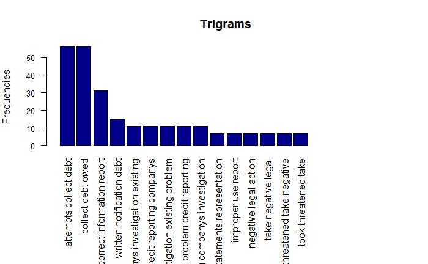

```r
#create the graph plotting fucntion

plotthegraph <- function(data,title,num){
  df <- data[order(-data$frequency),][1:num,]
  barplot(df[1:num,]$freq, las = 2, names.arg = df[1:num,]$word,
          col ="darkblue", main = title,
          ylab = "Frequencies",cex.axis = 0.8)
}

par(mar=c(10,4,4,2))

#plot the graph for Trigram
plotthegraph(IssueTrigramfreq,"Trigrams",20)
```